# Cloud Computing

Fundamentals of Data Science

MTH-361D | Spring 2025 | University of Portland

January 17, 2025

# Objectives

- **Introduce R and R Studio**
- **Introduce the Posit Cloud**
- **Introduce R Scripting**
- **Mini-Assignment: Create R Scripts**

# Previously…

The guiding principle of data science is the data science life cycle.

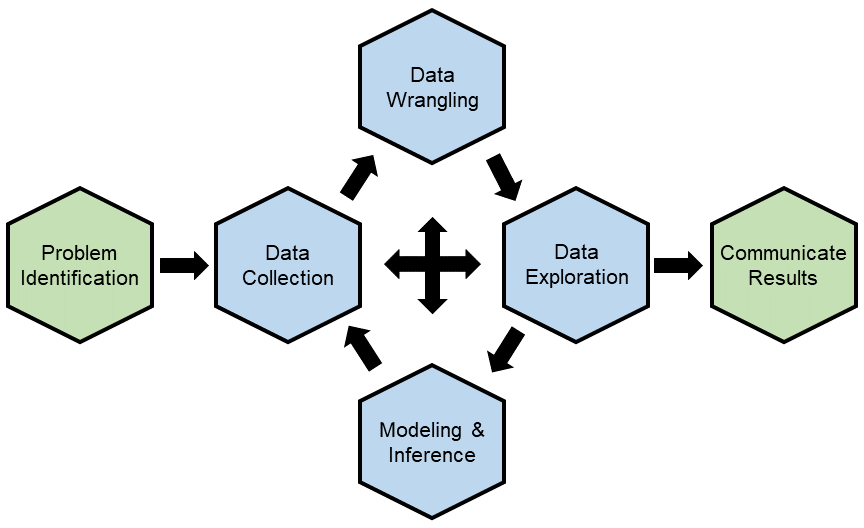

The Data Science Life Cycle

# R as a Tool for Statistics

### Why R?

- **Open-source and Free:** Accessible to everyone.
- **Designed for Statistics:** Built with statistical analysis in mind.
- **Extensive Libraries:** Thousands of packages available.
- **Data Visualization:** Easy and powerful plotting capabilities.
- **Active Community:** Help is just a forum post away.

# RStudio, a User-Friendly Interface

### What is R Studio?

**Integrated Development Environment (IDE):** Built specifically for R.

**Cross-Platform:** Available on Windows, macOS, and Linux.

**User-Friendly:** Simplifies coding, debugging, and visualizations.

**Enhanced Productivity:** Tools for managing projects, data, and outputs.

# Basic Parts of R Studio

[figure not shown]

Basic Parts of R Studio

# Posit Cloud, a Cloud-Based Solution

### What is Posit Cloud?

- **Cloud-Based Platform:** Accessible from any device with an internet connection.
- **Developed by Posit (formerly RStudio):** Tailored for statistics and data science.
- **No Installation Needed:** Run R and RStudio directly in your browser.

### Why Use Posit Cloud?

- **Convenience:** No installation required; access RStudio instantly through the internet.
- **Consistency:** Same environment across devices.
- **Collaboration:** Share projects with students and instructors easily.
- **Cost-Effective:** Free tier available with premium options for advanced features.

# How Posit Cloud Works?

[figure not shown]

Posit Cloud Computing

# Basic Parts of Posit Cloud

[figure not shown]

Basic Parts of Posit Cloud

# R Studio Working Directory

**Where does your saved files automatically go?**

[figure not shown]

The Working Directory

# Creating an R Script

An R script is a file with an extension “.R”. It can contain lines of R commands that you can define and run individual lines or run multiple lines.

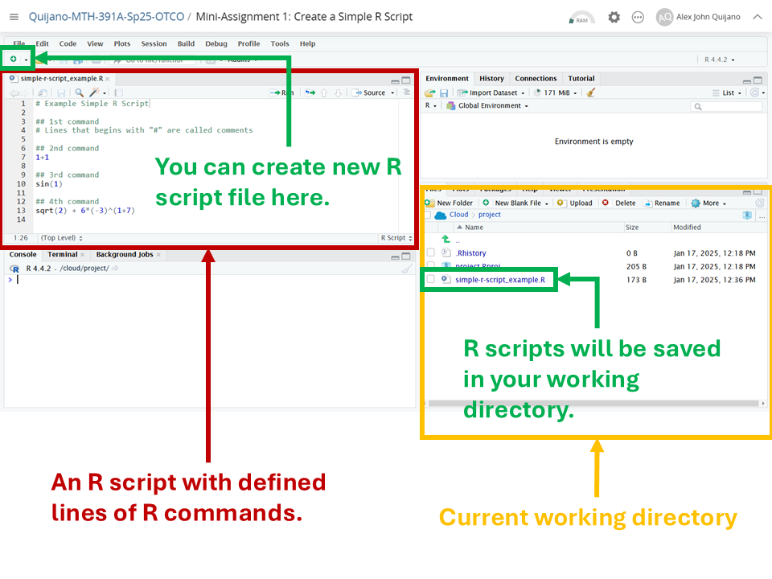

R Script File Example

# Running R on the Console vs Scripting

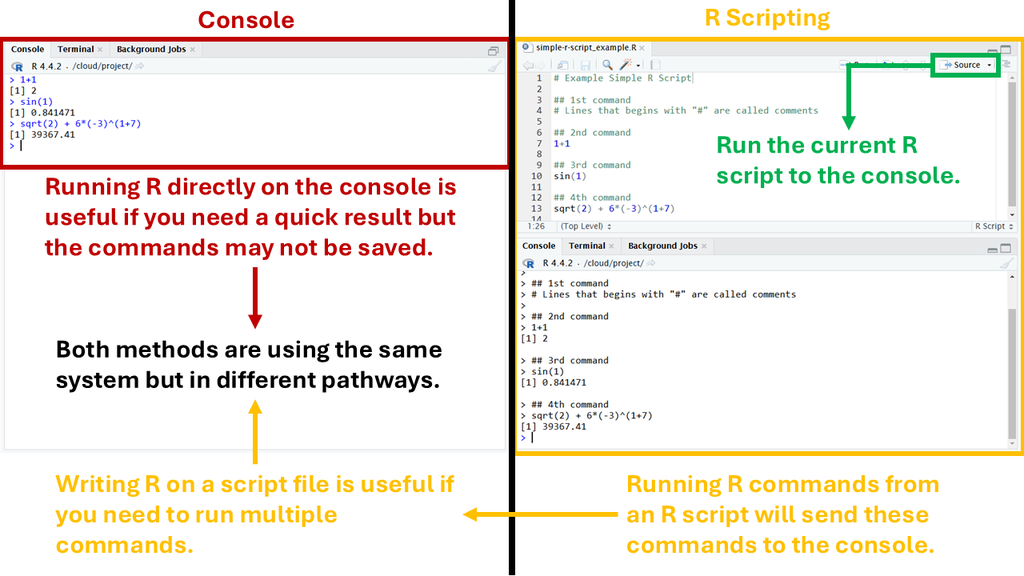

Running R Commands in Different Ways

# Mini-Assignment: Create a Simple R Script

1. Go to this course’s workspace in Posit Cloud and click the R Studio “Project” named *MA1: Create a Simple R Script*. This will create a copy for you.
2. Try rerunning the R script named *simple-r-script_example.R*.
3. Create a new R script and save it as *my-simple-r-script.R*. In your script:
   - Write in your name as a comment.
   - Create 5 single line R commands with comments as labels similar to the example.
4. Export your R script file, then submit it in Moodle.